# Diff_expAnalysis

Mohammed El Belbesy

### Libraries used in the analysis

```r
library(DESeq2)
library(RColorBrewer)
library(Biobase)
library(pheatmap)
library(annotables)
library(openxlsx)
library(rio)
library(tidyverse)
```

### Importing feature counts table

```r
counts_data<- read.table ("featurecounts.txt", header=T, row.names = 1)
```

```r
head(counts_GSEA)
```

|  | Geneid | Chr | Start | End | Strand | Length | X.home.stud03.NAS_MEB.workspace.rnaseq.mapped.RNA_NHEM_76_ACAGTG_L007.Aligned.sortedByCoord.out.bam | X.home.stud03.NAS_MEB.workspace.rnaseq.mapped.RNA_NHEM_77_GCCAAT_L007.Aligned.sortedByCoord.out.bam | X.home.stud03.NAS_MEB.workspace.rnaseq.mapped.RNA_Sbcl2_64_TAGCTT_L007.Aligned.sortedByCoord.out.bam | X.home.stud03.NAS_MEB.workspace.rnaseq.mapped.RNA_Sbcl2_70_TGACCA_L008.Aligned.sortedByCoord.out.bam | X.home.stud03.NAS_MEB.workspace.rnaseq.mapped.RNA_WM1158_68_CGATGT_L008.Aligned.sortedByCoord.out.bam | X.home.stud03.NAS_MEB.workspace.rnaseq.mapped.RNA_WM1158_74_ACTTGA_L007.Aligned.sortedByCoord.out.bam | X.home.stud03.NAS_MEB.workspace.rnaseq.mapped.RNA_WM1366_66_CTTGTA_L007.Aligned.sortedByCoord.out.bam | X.home.stud03.NAS_MEB.workspace.rnaseq.mapped.RNA_WM1366_72_GCCAAT_L008.Aligned.sortedByCoord.out.bam | X.home.stud03.NAS_MEB.workspace.rnaseq.mapped.RNA_WM3211_65_GGCTAC_L007.Aligned.sortedByCoord.out.bam | X.home.stud03.NAS_MEB.workspace.rnaseq.mapped.RNA_WM3211_71_ACAGTG_L008.Aligned.sortedByCoord.out.bam | X.home.stud03.NAS_MEB.workspace.rnaseq.mapped.RNA_WM793_67_ATCACG_L008.Aligned.sortedByCoord.out.bam | X.home.stud03.NAS_MEB.workspace.rnaseq.mapped.RNA_WM793_73_CAGATC_L008.Aligned.sortedByCoord.out.bam | X.home.stud03.NAS_MEB.workspace.rnaseq.mapped.RNA_WM9_69_TTAGGC_L008.Aligned.sortedByCoord.out.bam | X.home.stud03.NAS_MEB.workspace.rnaseq.mapped.RNA_WM9_75_GATCAG_L007.Aligned.sortedByCoord.out.bam |
| --- | --- | --- | --- | --- | --- | --- | --- | --- | --- | --- | --- | --- | --- | --- | --- | --- | --- | --- | --- | --- |
| 1 | ENSG00000223972.5 | chr1;chr1;chr1;chr1;chr1;chr1;chr1;chr1;chr1 | 11869;12010;12179;12613;12613;12975;13221;13221;13453 | 12227;12057;12227;12721;12697;13052;13374;14409;13670 | +;+;+;+;+;+;+;+;+ | 1735 | 2 | 0 | 2 | 1 | 2 | 2 | 3 | 5 | 1 | 0 | 1 | 1 | 0 | 2 |
| 2 | ENSG00000227232.5 | chr1;chr1;chr1;chr1;chr1;chr1;chr1;chr1;chr1;chr1;chr1 | 14404;15005;15796;16607;16858;17233;17606;17915;18268;24738;29534 | 14501;15038;15947;16765;17055;17368;17742;18061;18366;24891;29570 | -;-;-;-;-;-;-;-;-;-;- | 1351 | 7 | 9 | 10 | 9 | 13 | 5 | 5 | 10 | 7 | 4 | 4 | 5 | 8 | 5 |
| 3 | ENSG00000278267.1 | chr1 | 17369 | 17436 | - | 68 | 1 | 0 | 0 | 0 | 0 | 1 | 0 | 2 | 0 | 0 | 0 | 1 | 0 | 1 |
| 4 | ENSG00000243485.5 | chr1;chr1;chr1;chr1;chr1 | 29554;30267;30564;30976;30976 | 30039;30667;30667;31109;31097 | +;+;+;+;+ | 1021 | 0 | 0 | 1 | 1 | 1 | 2 | 0 | 0 | 0 | 0 | 0 | 0 | 0 | 1 |
| 5 | ENSG00000284332.1 | chr1 | 30366 | 30503 | + | 138 | 0 | 0 | 0 | 0 | 0 | 0 | 0 | 0 | 0 | 0 | 0 | 0 | 0 | 0 |
| 6 | ENSG00000237613.2 | chr1;chr1;chr1;chr1;chr1 | 34554;35245;35277;35721;35721 | 35174;35481;35481;36073;36081 | -;-;-;-;- | 1219 | 0 | 0 | 0 | 0 | 0 | 0 | 0 | 0 | 0 | 0 | 0 | 0 | 0 | 0 |

|  | Geneid <chr> | Chr <chr> |  |
| --- | --- | --- | --- |
| 1 | ENSG00000223972.5 | chr1;chr1;chr1;chr1;chr1;chr1;chr1;chr1;chr1 |  |
| 2 | ENSG00000227232.5 | chr1;chr1;chr1;chr1;chr1;chr1;chr1;chr1;chr1;chr1;chr1 |  |
| 3 | ENSG00000278267.1 | chr1 |  |
| 4 | ENSG00000243485.5 | chr1;chr1;chr1;chr1;chr1 |  |
| 5 | ENSG00000284332.1 | chr1 |  |
| 6 | ENSG00000237613.2 | chr1;chr1;chr1;chr1;chr1 |  |

6 rows | 1-3 of 20 columns

### Data Manipulation

```r
head(counts_data) #view the counts_data table
```

|  | Chr | Start | End | Strand | Length | X.home.stud03.NAS_MEB.workspace.rnaseq.mapped.RNA_NHEM_76_ACAGTG_L007.Aligned.sortedByCoord.out.bam | X.home.stud03.NAS_MEB.workspace.rnaseq.mapped.RNA_NHEM_77_GCCAAT_L007.Aligned.sortedByCoord.out.bam | X.home.stud03.NAS_MEB.workspace.rnaseq.mapped.RNA_Sbcl2_64_TAGCTT_L007.Aligned.sortedByCoord.out.bam | X.home.stud03.NAS_MEB.workspace.rnaseq.mapped.RNA_Sbcl2_70_TGACCA_L008.Aligned.sortedByCoord.out.bam | X.home.stud03.NAS_MEB.workspace.rnaseq.mapped.RNA_WM1158_68_CGATGT_L008.Aligned.sortedByCoord.out.bam | X.home.stud03.NAS_MEB.workspace.rnaseq.mapped.RNA_WM1158_74_ACTTGA_L007.Aligned.sortedByCoord.out.bam | X.home.stud03.NAS_MEB.workspace.rnaseq.mapped.RNA_WM1366_66_CTTGTA_L007.Aligned.sortedByCoord.out.bam | X.home.stud03.NAS_MEB.workspace.rnaseq.mapped.RNA_WM1366_72_GCCAAT_L008.Aligned.sortedByCoord.out.bam | X.home.stud03.NAS_MEB.workspace.rnaseq.mapped.RNA_WM3211_65_GGCTAC_L007.Aligned.sortedByCoord.out.bam | X.home.stud03.NAS_MEB.workspace.rnaseq.mapped.RNA_WM3211_71_ACAGTG_L008.Aligned.sortedByCoord.out.bam | X.home.stud03.NAS_MEB.workspace.rnaseq.mapped.RNA_WM793_67_ATCACG_L008.Aligned.sortedByCoord.out.bam | X.home.stud03.NAS_MEB.workspace.rnaseq.mapped.RNA_WM793_73_CAGATC_L008.Aligned.sortedByCoord.out.bam | X.home.stud03.NAS_MEB.workspace.rnaseq.mapped.RNA_WM9_69_TTAGGC_L008.Aligned.sortedByCoord.out.bam | X.home.stud03.NAS_MEB.workspace.rnaseq.mapped.RNA_WM9_75_GATCAG_L007.Aligned.sortedByCoord.out.bam |
| --- | --- | --- | --- | --- | --- | --- | --- | --- | --- | --- | --- | --- | --- | --- | --- | --- | --- | --- | --- |
| ENSG00000223972.5 | chr1;chr1;chr1;chr1;chr1;chr1;chr1;chr1;chr1 | 11869;12010;12179;12613;12613;12975;13221;13221;13453 | 12227;12057;12227;12721;12697;13052;13374;14409;13670 | +;+;+;+;+;+;+;+;+ | 1735 | 2 | 0 | 2 | 1 | 2 | 2 | 3 | 5 | 1 | 0 | 1 | 1 | 0 | 2 |
| ENSG00000227232.5 | chr1;chr1;chr1;chr1;chr1;chr1;chr1;chr1;chr1;chr1;chr1 | 14404;15005;15796;16607;16858;17233;17606;17915;18268;24738;29534 | 14501;15038;15947;16765;17055;17368;17742;18061;18366;24891;29570 | -;-;-;-;-;-;-;-;-;-;- | 1351 | 7 | 9 | 10 | 9 | 13 | 5 | 5 | 10 | 7 | 4 | 4 | 5 | 8 | 5 |
| ENSG00000278267.1 | chr1 | 17369 | 17436 | - | 68 | 1 | 0 | 0 | 0 | 0 | 1 | 0 | 2 | 0 | 0 | 0 | 1 | 0 | 1 |
| ENSG00000243485.5 | chr1;chr1;chr1;chr1;chr1 | 29554;30267;30564;30976;30976 | 30039;30667;30667;31109;31097 | +;+;+;+;+ | 1021 | 0 | 0 | 1 | 1 | 1 | 2 | 0 | 0 | 0 | 0 | 0 | 0 | 0 | 1 |
| ENSG00000284332.1 | chr1 | 30366 | 30503 | + | 138 | 0 | 0 | 0 | 0 | 0 | 0 | 0 | 0 | 0 | 0 | 0 | 0 | 0 | 0 |
| ENSG00000237613.2 | chr1;chr1;chr1;chr1;chr1 | 34554;35245;35277;35721;35721 | 35174;35481;35481;36073;36081 | -;-;-;-;- | 1219 | 0 | 0 | 0 | 0 | 0 | 0 | 0 | 0 | 0 | 0 | 0 | 0 | 0 | 0 |

|  | Chr <chr> |  |
| --- | --- | --- |
| ENSG00000223972.5 | chr1;chr1;chr1;chr1;chr1;chr1;chr1;chr1;chr1 |  |
| ENSG00000227232.5 | chr1;chr1;chr1;chr1;chr1;chr1;chr1;chr1;chr1;chr1;chr1 |  |
| ENSG00000278267.1 | chr1 |  |
| ENSG00000243485.5 | chr1;chr1;chr1;chr1;chr1 |  |
| ENSG00000284332.1 | chr1 |  |
| ENSG00000237613.2 | chr1;chr1;chr1;chr1;chr1 |  |

6 rows | 1-2 of 19 columns

#### removing the first 5 columns

```r
counts_data <- counts_data [ ,6:ncol(counts_data)]
#head(counts_data)
```

#### Renamaming Columns

```r
colnames(counts_data) <- c("NHEM76","NHEM77","Sbcl2_64","Sbcl2_70","WM1158_68","WM1158_74","WM1366_66","WM1366_72","WM3211_65","WM3211_71","WM793_67","WM793_73","WM9_69","WM9_75")
```

```r
head(counts_data)
```

|  | NHEM76 | NHEM77 | Sbcl2_64 | Sbcl2_70 | WM1158_68 | WM1158_74 | WM1366_66 | WM1366_72 | WM3211_65 | WM3211_71 | WM793_67 | WM793_73 | WM9_69 | WM9_75 |
| --- | --- | --- | --- | --- | --- | --- | --- | --- | --- | --- | --- | --- | --- | --- |
| ENSG00000223972.5 | 2 | 0 | 2 | 1 | 2 | 2 | 3 | 5 | 1 | 0 | 1 | 1 | 0 | 2 |
| ENSG00000227232.5 | 7 | 9 | 10 | 9 | 13 | 5 | 5 | 10 | 7 | 4 | 4 | 5 | 8 | 5 |
| ENSG00000278267.1 | 1 | 0 | 0 | 0 | 0 | 1 | 0 | 2 | 0 | 0 | 0 | 1 | 0 | 1 |
| ENSG00000243485.5 | 0 | 0 | 1 | 1 | 1 | 2 | 0 | 0 | 0 | 0 | 0 | 0 | 0 | 1 |
| ENSG00000284332.1 | 0 | 0 | 0 | 0 | 0 | 0 | 0 | 0 | 0 | 0 | 0 | 0 | 0 | 0 |
| ENSG00000237613.2 | 0 | 0 | 0 | 0 | 0 | 0 | 0 | 0 | 0 | 0 | 0 | 0 | 0 | 0 |

|  | NHEM76 <int> | NHEM77 <int> | Sbcl2_64 <int> | Sbcl2_70 <int> | WM1158_68 <int> | WM1158_74 <int> | WM1366_66 <int> | WM1366_72 <int> |  |
| --- | --- | --- | --- | --- | --- | --- | --- | --- | --- |
| ENSG00000223972.5 | 2 | 0 | 2 | 1 | 2 | 2 | 3 | 5 |  |
| ENSG00000227232.5 | 7 | 9 | 10 | 9 | 13 | 5 | 5 | 10 |  |
| ENSG00000278267.1 | 1 | 0 | 0 | 0 | 0 | 1 | 0 | 2 |  |
| ENSG00000243485.5 | 0 | 0 | 1 | 1 | 1 | 2 | 0 | 0 |  |
| ENSG00000284332.1 | 0 | 0 | 0 | 0 | 0 | 0 | 0 | 0 |  |
| ENSG00000237613.2 | 0 | 0 | 0 | 0 | 0 | 0 | 0 | 0 |  |

6 rows | 1-9 of 14 columns

#### Reordering coloumns

```r
# Getting columns names and positions
colnames(counts_data)
```

```
 [1] "NHEM76"    "NHEM77"    "Sbcl2_64"  "Sbcl2_70"  "WM1158_68"
 [6] "WM1158_74" "WM1366_66" "WM1366_72" "WM3211_65" "WM3211_71"
[11] "WM793_67"  "WM793_73"  "WM9_69"    "WM9_75"
```

```r
#Rearranging by columns positions
counts_data <- counts_data[, c(1, 2, 3, 4, 7, 8, 9, 10, 11, 12, 13, 14, 5, 6)]
```

This step is important, to be able to group them when creating the metadata needed for the DESeq2 object.

```r
head(counts_data)
```

|  | NHEM76 | NHEM77 | Sbcl2_64 | Sbcl2_70 | WM1366_66 | WM1366_72 | WM3211_65 | WM3211_71 | WM793_67 | WM793_73 | WM9_69 | WM9_75 | WM1158_68 | WM1158_74 |
| --- | --- | --- | --- | --- | --- | --- | --- | --- | --- | --- | --- | --- | --- | --- |
| ENSG00000223972.5 | 2 | 0 | 2 | 1 | 3 | 5 | 1 | 0 | 1 | 1 | 0 | 2 | 2 | 2 |
| ENSG00000227232.5 | 7 | 9 | 10 | 9 | 5 | 10 | 7 | 4 | 4 | 5 | 8 | 5 | 13 | 5 |
| ENSG00000278267.1 | 1 | 0 | 0 | 0 | 0 | 2 | 0 | 0 | 0 | 1 | 0 | 1 | 0 | 1 |
| ENSG00000243485.5 | 0 | 0 | 1 | 1 | 0 | 0 | 0 | 0 | 0 | 0 | 0 | 1 | 1 | 2 |
| ENSG00000284332.1 | 0 | 0 | 0 | 0 | 0 | 0 | 0 | 0 | 0 | 0 | 0 | 0 | 0 | 0 |
| ENSG00000237613.2 | 0 | 0 | 0 | 0 | 0 | 0 | 0 | 0 | 0 | 0 | 0 | 0 | 0 | 0 |

|  | NHEM76 <int> | NHEM77 <int> | Sbcl2_64 <int> | Sbcl2_70 <int> | WM1366_66 <int> | WM1366_72 <int> | WM3211_65 <int> | WM3211_71 <int> |  |
| --- | --- | --- | --- | --- | --- | --- | --- | --- | --- |
| ENSG00000223972.5 | 2 | 0 | 2 | 1 | 3 | 5 | 1 | 0 |  |
| ENSG00000227232.5 | 7 | 9 | 10 | 9 | 5 | 10 | 7 | 4 |  |
| ENSG00000278267.1 | 1 | 0 | 0 | 0 | 0 | 2 | 0 | 0 |  |
| ENSG00000243485.5 | 0 | 0 | 1 | 1 | 0 | 0 | 0 | 0 |  |
| ENSG00000284332.1 | 0 | 0 | 0 | 0 | 0 | 0 | 0 | 0 |  |
| ENSG00000237613.2 | 0 | 0 | 0 | 0 | 0 | 0 | 0 | 0 |  |

6 rows | 1-9 of 14 columns

#### Pre-Filtering

Filtering out the lowly expressed genes and checking the dimension of the data set. We will make it more than 10 because lowly expressed genes are kind of hard to measure for differential expression e.g 1 read or 2 reads.

```r
dim(counts_data) #before
```

```
[1] 58721    14
```

```r
counts_data <- counts_data [rowSums(counts_data) > 10, ]
dim(counts_data) #after
```

```
[1] 26574    14
```

rows is reduced from 58721 to 26574

#### Getting rid off Enseml IDs version

```r
tmp=gsub("\\..*","",row.names(counts_data))
```

```r
rownames(counts_data) <- tmp
head(counts_data)
```

|  | NHEM76 | NHEM77 | Sbcl2_64 | Sbcl2_70 | WM1366_66 | WM1366_72 | WM3211_65 | WM3211_71 | WM793_67 | WM793_73 | WM9_69 | WM9_75 | WM1158_68 | WM1158_74 |
| --- | --- | --- | --- | --- | --- | --- | --- | --- | --- | --- | --- | --- | --- | --- |
| ENSG00000223972 | 2 | 0 | 2 | 1 | 3 | 5 | 1 | 0 | 1 | 1 | 0 | 2 | 2 | 2 |
| ENSG00000227232 | 7 | 9 | 10 | 9 | 5 | 10 | 7 | 4 | 4 | 5 | 8 | 5 | 13 | 5 |
| ENSG00000241860 | 0 | 2 | 2 | 2 | 2 | 5 | 1 | 1 | 2 | 2 | 4 | 0 | 9 | 1 |
| ENSG00000279457 | 4 | 9 | 19 | 13 | 2 | 2 | 2 | 6 | 5 | 4 | 12 | 2 | 7 | 3 |
| ENSG00000228463 | 11 | 20 | 1 | 3 | 10 | 5 | 7 | 2 | 6 | 2 | 7 | 3 | 2 | 0 |
| ENSG00000237094 | 3 | 2 | 5 | 5 | 7 | 25 | 6 | 11 | 1 | 4 | 16 | 6 | 20 | 15 |

|  | NHEM76 <int> | NHEM77 <int> | Sbcl2_64 <int> | Sbcl2_70 <int> | WM1366_66 <int> | WM1366_72 <int> | WM3211_65 <int> | WM3211_71 <int> | WM793_67 <int> |  |
| --- | --- | --- | --- | --- | --- | --- | --- | --- | --- | --- |
| ENSG00000223972 | 2 | 0 | 2 | 1 | 3 | 5 | 1 | 0 | 1 |  |
| ENSG00000227232 | 7 | 9 | 10 | 9 | 5 | 10 | 7 | 4 | 4 |  |
| ENSG00000241860 | 0 | 2 | 2 | 2 | 2 | 5 | 1 | 1 | 2 |  |
| ENSG00000279457 | 4 | 9 | 19 | 13 | 2 | 2 | 2 | 6 | 5 |  |
| ENSG00000228463 | 11 | 20 | 1 | 3 | 10 | 5 | 7 | 2 | 6 |  |
| ENSG00000237094 | 3 | 2 | 5 | 5 | 7 | 25 | 6 | 11 | 1 |  |

6 rows | 1-10 of 14 columns

### DESeq2 analysis Workflow

- To perform any analysis with DESeq2, we need to create a DESeq2 object by providing the raw counts, metadata, and design formula.
- DESeq2 object is a list-like object.

#### Creating a metadata frame

```r
colData <- data.frame(row.names=colnames(counts_data), group, con)
colData
```

|  | group | con |
| --- | --- | --- |
| NHEM76 | NHEM | normal |
| NHEM77 | NHEM | normal |
| Sbcl2_64 | Sbcl2 | radial |
| Sbcl2_70 | Sbcl2 | radial |
| WM1366_66 | WM1366 | vertical |
| WM1366_72 | WM1366 | vertical |
| WM3211_65 | WM3211 | vertical |
| WM3211_71 | WM3211 | vertical |
| WM793_67 | WM793 | vertical |
| WM793_73 | WM793 | vertical |

[output cut: 4 more lines]

|  | group <fctr> | con <fctr> |  |  |
| --- | --- | --- | --- | --- |
| NHEM76 | NHEM | normal |  |  |
| NHEM77 | NHEM | normal |  |  |
| Sbcl2_64 | Sbcl2 | radial |  |  |
| Sbcl2_70 | Sbcl2 | radial |  |  |
| WM1366_66 | WM1366 | vertical |  |  |
| WM1366_72 | WM1366 | vertical |  |  |
| WM3211_65 | WM3211 | vertical |  |  |
| WM3211_71 | WM3211 | vertical |  |  |
| WM793_67 | WM793 | vertical |  |  |
| WM793_73 | WM793 | vertical |  |  |

1-10 of 14 rows

colData variable will be our metadata

```r
colData <- data.frame(row.names=colnames(counts_data), group, con)
colData
```

|  | group | con |
| --- | --- | --- |
| NHEM76 | NHEM | normal |
| NHEM77 | NHEM | normal |
| Sbcl2_64 | Sbcl2 | radial |
| Sbcl2_70 | Sbcl2 | radial |
| WM1366_66 | WM1366 | vertical |
| WM1366_72 | WM1366 | vertical |
| WM3211_65 | WM3211 | vertical |
| WM3211_71 | WM3211 | vertical |
| WM793_67 | WM793 | vertical |
| WM793_73 | WM793 | vertical |

[output cut: 4 more lines]

|  | group <fctr> | con <fctr> |  |  |
| --- | --- | --- | --- | --- |
| NHEM76 | NHEM | normal |  |  |
| NHEM77 | NHEM | normal |  |  |
| Sbcl2_64 | Sbcl2 | radial |  |  |
| Sbcl2_70 | Sbcl2 | radial |  |  |
| WM1366_66 | WM1366 | vertical |  |  |
| WM1366_72 | WM1366 | vertical |  |  |
| WM3211_65 | WM3211 | vertical |  |  |
| WM3211_71 | WM3211 | vertical |  |  |
| WM793_67 | WM793 | vertical |  |  |
| WM793_73 | WM793 | vertical |  |  |

1-10 of 14 rows

```r
#Checking whether the row names in colData matches to column names in counts_data
all(colnames(counts_data) %in% rownames(colData))
```

```
[1] TRUE
```

```r
# Ensure that the sample names are in the same order in both datasets,
all(colnames(counts_data) == rownames(colData))
```

```
[1] TRUE
```

If not, we can modify this with match() function.

#### Colors for plots

```r
mycols <- brewer.pal(11, "Set3")[1:length(unique(group))]
```

### Create DESeqDataSet Object

- As input, the DESeq2 package expects count data as obtained, e.g., from RNA-seq in the form of a matrix of integer values which should be un-normalized counts.
- Because the DESeq2 model corrects for library size internally, converted or normalized numbers should not be given as input, such as counts scaled by library size.

```r
dds<- DESeqDataSetFromMatrix (countData= counts_data, colData=colData, design= ~ con)
```

```r
design(dds)
```

```
~con
```

### Checking the design of your DESEeqDataSets

```r
design(dds)
```

```
~con
```

- We now have a DESeq2 object (dds) containing our raw counts and metadata, and we want to do quality control on our samples. As a result, the normalized counts must be generated (normalized for library size, which is the total number of gene counts per sample, while accounting for library composition).
- To evaluate the sample-level quality control matrix, the first step in the process is to normalize the raw counts.

what is meant by normalized raw counts ?

- The raw counts represent the number of reads aligning to each gene and should be proportional to the RNA expression in the sample; however, there are additional factors that can influence the number of genes aligning to each gene besides RNA expression.
- Using normalization methods, we may alter the count data to remove the influence of these factors and remove the overall counts.

**Library depth**, **gene length**, and **RNA composition** are three of the most important parameters to consider when normalizing count data.

- If the library sizes of two samples differ, many more reads may be mapped to genes in one sample than in the other.

In terms of **gene length**, a longer gene results in a longer transcript, which results in more fragments for sequencing. As a result, a longer gene with the same amount of expression will have more counts than a shorter gene. Therefore, when comparing the expression levels of various genes, the lengths of the genes must be taken into account.

#### Creating the estimateSizeFactors.

- When adjusting for **library size**, the library’s composition is also crucial to consider. Many normalization methods that are not resistant to outliers can be skewed by a few highly expressed genes.
- Normalization for the majority of genes would be skewed by the highly expressed DE gene if we only divided our counts by the total number of reads. As a result, we need to use a technique that is resistant to these outlier genes when performing a DE analysis.
- DESeq2 normalizes using the “median of ratios” method. which accounts for library size when computing raw counts and is resistant to large numbers of differentially expressed genes.
- For normalization, the raw counts of each sample will be divided by the sample-specific size factor.

#### Estimating size factor

```r
dds <- estimateSizeFactors(dds)
sizeFactors(dds)# to view the size factors used for normalization
```

```
   NHEM76    NHEM77  Sbcl2_64  Sbcl2_70 WM1366_66 WM1366_72 WM3211_65
1.1675968 1.7287595 1.1541503 1.2013835 0.6304523 1.2699113 0.7400715
WM3211_71  WM793_67  WM793_73    WM9_69    WM9_75 WM1158_68 WM1158_74
0.8725916 1.0196053 1.0923370 1.5843539 0.4016549 1.4756025 0.8078638
```

```r
colData(dds)
```

```
DataFrame with 14 rows and 3 columns
             group        con sizeFactor
          <factor>   <factor>  <numeric>
NHEM76      NHEM     normal     1.167597
NHEM77      NHEM     normal     1.728759
Sbcl2_64    Sbcl2    radial     1.154150
Sbcl2_70    Sbcl2    radial     1.201383
WM1366_66   WM1366   vertical   0.630452
...            ...        ...        ...
WM793_73    WM793  vertical     1.092337
WM9_69      WM9    metastasis   1.584354
WM9_75      WM9    metastasis   0.401655
WM1158_68   WM1158 metastasis   1.475603
WM1158_74   WM1158 metastasis   0.807864
```

```r
head(counts(dds)) #un-normalized
```

```
                NHEM76 NHEM77 Sbcl2_64 Sbcl2_70 WM1366_66 WM1366_72
ENSG00000223972      2      0        2        1         3         5
ENSG00000227232      7      9       10        9         5        10
ENSG00000241860      0      2        2        2         2         5
ENSG00000279457      4      9       19       13         2         2
ENSG00000228463     11     20        1        3        10         5
ENSG00000237094      3      2        5        5         7        25
                WM3211_65 WM3211_71 WM793_67 WM793_73 WM9_69 WM9_75
ENSG00000223972         1         0        1        1      0      2
ENSG00000227232         7         4        4        5      8      5
ENSG00000241860         1         1        2        2      4      0
ENSG00000279457         2         6        5        4     12      2
ENSG00000228463         7         2        6        2      7      3
ENSG00000237094         6        11        1        4     16      6
                WM1158_68 WM1158_74
ENSG00000223972         2         2
ENSG00000227232        13         5
ENSG00000241860         9         1
ENSG00000279457         7         3
ENSG00000228463         2         0
ENSG00000237094        20        15
```

#### Extract the normalized counts

Now we have the size factors been calculated, and added to the DESeq2 object, the normalized counts can be extracted from it using the counts() function.

```r
norm_counts<- counts(dds, normalized = TRUE)
head(norm_counts)
```

```
                 NHEM76    NHEM77   Sbcl2_64   Sbcl2_70 WM1366_66
ENSG00000223972 1.71292  0.000000  1.7328766  0.8323737  4.758488
ENSG00000227232 5.99522  5.206045  8.6643831  7.4913633  7.930814
ENSG00000241860 0.00000  1.156899  1.7328766  1.6647474  3.172326
ENSG00000279457 3.42584  5.206045 16.4623279 10.8208581  3.172326
ENSG00000228463 9.42106 11.568989  0.8664383  2.4971211 15.861628
ENSG00000237094 2.56938  1.156899  4.3321916  4.1618685 11.103139
                WM1366_72 WM3211_65 WM3211_71  WM793_67  WM793_73
ENSG00000223972  3.937283  1.351221  0.000000 0.9807716 0.9154684
ENSG00000227232  7.874565  9.458546  4.584046 3.9230866 4.5773421
ENSG00000241860  3.937283  1.351221  1.146011 1.9615433 1.8309368
ENSG00000279457  1.574913  2.702442  6.876069 4.9038582 3.6618737
ENSG00000228463  3.937283  9.458546  2.292023 5.8846298 1.8309368
ENSG00000237094 19.686414  8.107325 12.606126 0.9807716 3.6618737
                   WM9_69    WM9_75 WM1158_68 WM1158_74
ENSG00000223972  0.000000  4.979399  1.355379  2.475665
ENSG00000227232  5.049377 12.448497  8.809960  6.189162
ENSG00000241860  2.524688  0.000000  6.099203  1.237832
ENSG00000279457  7.574065  4.979399  4.743825  3.713497
ENSG00000228463  4.418205  7.469098  1.355379  0.000000
ENSG00000237094 10.098754 14.938196 13.553785 18.567486
```

```r
sum(is.na(norm_counts))
```

```
[1] 0
```

#### GSEA save normalized counts for the GSEA

```r
gsea_file <- read_delim("ddsNormSF.txt", "\t", escape_double = FALSE, trim_ws = TRUE)
```

```r
head(gsea_file)
```

| ...1 | NHEM76 | NHEM77 | Sbcl2_64 | Sbcl2_70 | WM1366_66 | WM1366_72 | WM3211_65 | WM3211_71 | WM793_67 | WM793_73 | WM9_69 | WM9_75 | WM1158_68 | WM1158_74 |
| --- | --- | --- | --- | --- | --- | --- | --- | --- | --- | --- | --- | --- | --- | --- |
| ENSG00000223972 | 1.71292 | 0.000000 | 1.7328766 | 0.8323737 | 4.758488 | 3.937283 | 1.351221 | 0.000000 | 0.9807716 | 0.9154684 | 0.000000 | 4.979399 | 1.355379 | 2.475665 |
| ENSG00000227232 | 5.99522 | 5.206045 | 8.6643831 | 7.4913633 | 7.930814 | 7.874565 | 9.458546 | 4.584046 | 3.9230866 | 4.5773421 | 5.049377 | 12.448497 | 8.809960 | 6.189162 |
| ENSG00000241860 | 0.00000 | 1.156899 | 1.7328766 | 1.6647474 | 3.172326 | 3.937283 | 1.351221 | 1.146011 | 1.9615433 | 1.8309368 | 2.524688 | 0.000000 | 6.099203 | 1.237832 |
| ENSG00000279457 | 3.42584 | 5.206045 | 16.4623279 | 10.8208581 | 3.172326 | 1.574913 | 2.702442 | 6.876069 | 4.9038582 | 3.6618737 | 7.574065 | 4.979399 | 4.743825 | 3.713497 |
| ENSG00000228463 | 9.42106 | 11.568989 | 0.8664383 | 2.4971211 | 15.861628 | 3.937283 | 9.458546 | 2.292023 | 5.8846298 | 1.8309368 | 4.418205 | 7.469098 | 1.355379 | 0.000000 |
| ENSG00000237094 | 2.56938 | 1.156899 | 4.3321916 | 4.1618685 | 11.103139 | 19.686414 | 8.107325 | 12.606126 | 0.9807716 | 3.6618737 | 10.098754 | 14.938196 | 13.553785 | 18.567486 |

| ...1 <chr> | NHEM76 <dbl> | NHEM77 <dbl> | Sbcl2_64 <dbl> | Sbcl2_70 <dbl> | WM1366_66 <dbl> | WM1366_72 <dbl> | WM3211_65 <dbl> | WM3211_71 <dbl> |  |
| --- | --- | --- | --- | --- | --- | --- | --- | --- | --- |
| ENSG00000223972 | 1.71292 | 0.000000 | 1.7328766 | 0.8323737 | 4.758488 | 3.937283 | 1.351221 | 0.000000 |  |
| ENSG00000227232 | 5.99522 | 5.206045 | 8.6643831 | 7.4913633 | 7.930814 | 7.874565 | 9.458546 | 4.584046 |  |
| ENSG00000241860 | 0.00000 | 1.156899 | 1.7328766 | 1.6647474 | 3.172326 | 3.937283 | 1.351221 | 1.146011 |  |
| ENSG00000279457 | 3.42584 | 5.206045 | 16.4623279 | 10.8208581 | 3.172326 | 1.574913 | 2.702442 | 6.876069 |  |
| ENSG00000228463 | 9.42106 | 11.568989 | 0.8664383 | 2.4971211 | 15.861628 | 3.937283 | 9.458546 | 2.292023 |  |
| ENSG00000237094 | 2.56938 | 1.156899 | 4.3321916 | 4.1618685 | 11.103139 | 19.686414 | 8.107325 | 12.606126 |  |

6 rows | 1-9 of 15 columns

```r
write.table(gsea_file, file = "gsea_inputfile.txt", quote = FALSE, row.names = FALSE, sep = "\t")
```

```r
#test12 <- read.delim("ddsNormSF2.txt")
#head(test12)
#read_delim("file.txt", "\t", escape_double = FALSE, trim_ws = TRUE)
#write.table(df, file = "df.txt", quote = FALSE, row.names = FALSE, sep = "\t")
```

```r
#save the normalized counts in a table
#write.table(norm_counts, file = "C:/Users/melbe/Documents/R/R_Projects/Diff_Exp_thesis/ddsNormSF2.txt", sep = "\t", col.names = NA)
```

Now that we’ve normalized the counts, we can move on to the next step of our analysis. We can now compare the counts between the different samples because the counts have been normalized for library size.

#### Quality assessment of our samples

- To measure the quality of our experiment, we can look at how the samples relate in terms of gene expression.
- Visualization approaches for unsupervised clustering analyses, such as hierarchical heatmaps and principal component analysis PCA, are used to do this.
- These QC approaches are used to determine how comparable the biological replicates are to one another, as well as to detect outlier samples and major sources of variation in the data set.
- To better the visualization of the clustering, we should first use the log to transform the normalized counts before using these Visualization methods. DESeq2 applies a variance stabilizing transformation (VST) to RNA-Seq data, which is a logarithmic transformation that reduces variance across the mean.

#### Transform the normalized counts

The DESeq2 vst() function on the DESeq2 object can be used to transform the normalized counts. The blind = True argument indicates that the transformation should be blind to the sample information provided in the design formula; this argument should be stated during the quality evaluation.

```r
vsd <- vst(dds, blind = TRUE)
```

#### Heatmaps

- To assess the similarity and gene expression between different samples in a dataset, hierarchical clustering with heatmaps is used.
- This method is used to determine how similar replicates are to one another and whether samples from various sample groups cluster together or separately. The heatmap is made by combining the gene expression correlation values for all pairwise combinations of samples in the data set, with 1 being the perfect correlation.
- The heatmap’s colors reflect the correlation values, while the hierarchical tree shows which samples are more similar to one another. The biological replicates should be grouped together, whereas the sample conditions should be separated. Because the majority of genes should not be differentially expressed, samples should have a high correlation.
- Samples having correlation values less than 0.8 may need to be investigated further to see if they are outliers or have contamination.

##### Extract the matrix of transformed counts

To make a heatmap, we’ll use the assay() function to extract the VST-transformed normalized counts as a matrix from a vsd object. The pairwise correlation values between each pair of samples can then be computed using the cor() function.

```r
vsd_mat <- assay(vsd)
```

#### Computing the correlation values between samples

```r
vsd_cor <- cor(vsd_mat)
```

##### Plot the heatmap

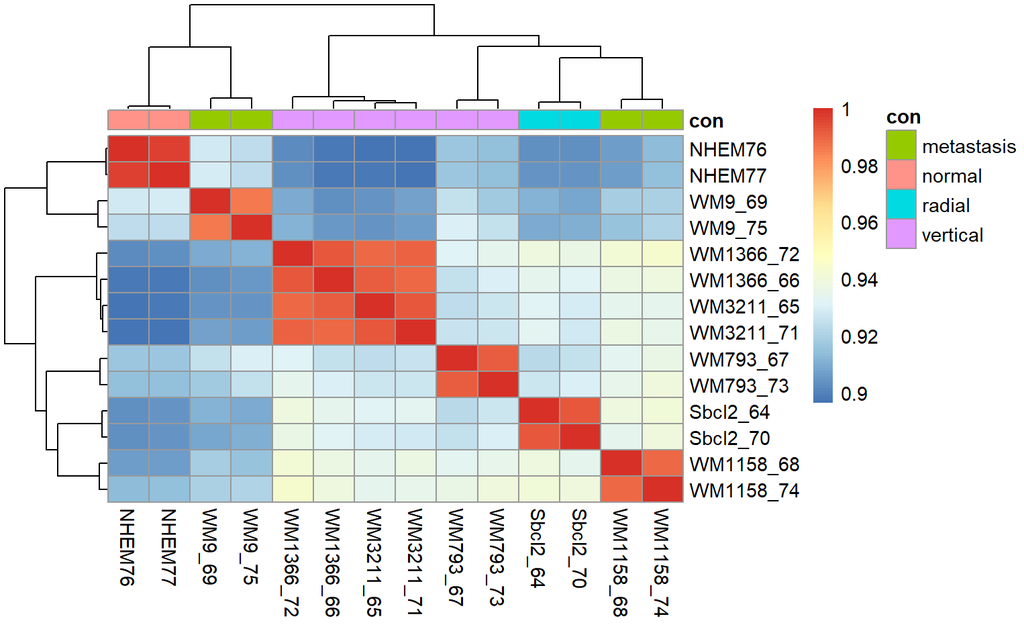

```r
pheatmap(vsd_cor, annotation = dplyr::select(colData, con))
```

#### Pricipal component analysis PCA

- In order to continue evaluating the quality of our samples, we will use PCA to see how our samples cluster and whether our condition of interest corresponds to the principal components explaining the most variation in the data.
- PCA is a technique for emphasizing the variation in a dataset. The first principal component, or PCA1, represents the greatest amount of variance in the data.
- we could plot the normalized counts of every gene for one sample in the x-axis and the other sample on the y-axis. PC2, the dataset’s second most variation, must be perpendicular to PC1 in order to best describe the variance in the dataset not included in PC1. PC2 has a much smaller spread.
- The number of principal components in the dataset is equal to the number of samples, n. PC1 means plotting a line through n-dimensional space to find the greatest amount of variation.
- The principal component with the most variant genes has the greatest influence on the direction of that principal component. Genes are given quantitative scores based on how much they influence the various PCs. The product of the influence and the normalized read counts for each gene is multiplied by all genes to get a ‘per sample’ PC value.We usually plot these per-sample PC values for PCA.
- The gene expression profiles of samples that cluster together are more similar than those of samples that cluster apart, especially for the most variant genes. As we hope to see replicated clusters together and conditions to separate on PC1, this is a good method to explore the quality of the data.
- This method can also be used to identify sample outliers and major sources of variation.

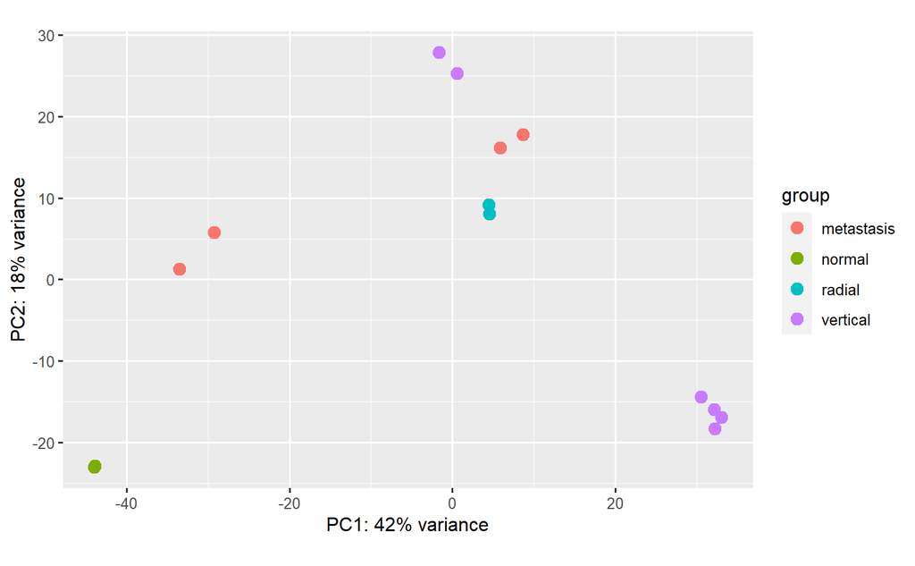

```r
plotPCA(vsd, intgroup = 'con')
```

#### DE analysis

##### fitting the raw counts to the DESeq2 model.

- Estimated size factors for each gene, as well as the variation in expression across replicates were evaluated. The data can then be fitted to the negative binomial model using these calculations.
- A DESeq2 object containing the raw data, metadata, and *design* formula has already been created. The design formula tells DESeq2 which known major source of variation to control, for, or regress out, as well as which condition of interest to use for differential expression testing.

```r
#run the analysis
dds <- DESeq(dds)
```

The final DESeq2 object will have all of the data required to perform differential expression analysis between different sample groups.

```r
resultsNames(dds)
```

```
[1] "Intercept"                  "con_normal_vs_metastasis"
[3] "con_radial_vs_metastasis"   "con_vertical_vs_metastasis"
```

### set factor level

```r
dds$con <- relevel(dds$con, ref = "normal")
```

```r
#run the analysis again
dds <- DESeq(dds)
```

```
found already estimated dispersions, replacing these
```

```r
resultsNames(dds)
```

```
[1] "Intercept"                "con_metastasis_vs_normal"
[3] "con_radial_vs_normal"     "con_vertical_vs_normal"
```

#### Exploring the results

- The raw counts are modeled using the dispersion estimates; we should investigate how the raw data will match the model.
- The purpose of DE analysis is to see if the mean expression of a gene differs between sample groups when there is variation within groups. This is accomplished by determining whether the difference in log2 fold changes between groups is significantly different from zero.
- The log2 fold changes are calculated by dividing the mean of one sample group by the mean of the other sample group. As a result, information regarding the mean and variation in the data is required to model the counts.

#### Plotting Dispersion

- We’ll look at the variance in gene expression relative to the mean to see how our data varies.
- Variance is the square of the standard deviation, representing how far away the expression of the individual samples, are from the means.

*The variance is expected to increase with the gene’s mean expression in RNA-Seq data. To observe this relationship, we can use the apply() function to calculate the means and variances for each gene in the normal samples. Then, using ggplot2, we create a data frame for plotting. The log10 scales can be used to plot the mean and variance for each gene.

- we can plot the mean and variance for each gene using the log10 scales.
- In the DESeq2 model, a metric called dispersion describes a measure of variance for a given mean to assess the variability in expression.
- Dispersion formula: Var = μ + α*μ^2 .

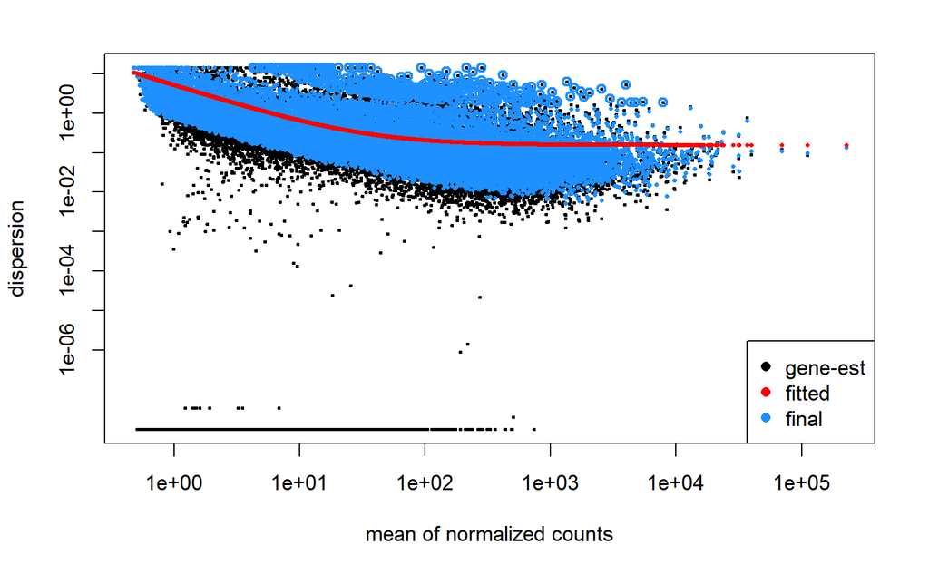

```r
plotDispEsts(dds)
```

*Extremely high dispersion values, encircled by blue circles, aren’t shrunk since there’s a chance the gene has more variability than others for biological or technical reasons, and lowering the variability could lead to false positives.

- The strength of the shrinkage is determined by the sample size and distance from the curve. A large number of replicates allows for more accurate estimation of the mean and variation, resulting in less shrinkage. In the figure, The dispersions decrease with increasing mean and cluster around the maximum likelihood (ML) line, indicating a satisfactory match.

#### First comparison Normal Vs radial growth phase “RGP”

we will try to find the significant genes during the development of cancer cells from melanocytes to the Radial growth phase.

#### Extraction of results (normal vs RGP)

- Now that we have explored the fit of our data to the model, we can extract the DE testing model.
- We can also get more precise foldchange estimates, which measure the expression of one sample group compared to another. The Wald test is used by DESeq2 to compare two sample groups for the condition of interest, in this case “normal and radial growth Phase.”

```r
#sadad
dds1_res <- results(dds, contrast = c("con", "radial", "normal"))
dds1_res
```

```
log2 fold change (MLE): con radial vs normal
Wald test p-value: con radial vs normal
DataFrame with 26574 rows and 6 columns
                  baseMean log2FoldChange     lfcSE      stat
                 <numeric>      <numeric> <numeric> <numeric>
ENSG00000223972    1.78799       0.710301  1.992192  0.356542
ENSG00000227232    7.01446       0.536886  0.733066  0.732383
ENSG00000241860    1.98683       1.378421  1.664696  0.828031
ENSG00000279457    5.70124       1.632679  0.796839  2.048945
ENSG00000228463    5.49010      -2.638075  1.296266 -2.035134
...                    ...            ...       ...       ...
ENSG00000198695  399.68416      -1.588101  0.476504 -3.332819
ENSG00000210194    2.94970      -1.894507  1.723122 -1.099462
ENSG00000198727 1411.29417      -1.208026  0.401252 -3.010640
ENSG00000210195    9.21425      -1.048826  0.793127 -1.322394
ENSG00000210196   58.66427      -0.208716  0.492520 -0.423773
                     pvalue      padj
                  <numeric> <numeric>
ENSG00000223972   0.7214345  0.851775
ENSG00000227232   0.4639346  0.663017
ENSG00000241860   0.4076527  0.612446
ENSG00000279457   0.0404674  0.130239
ENSG00000228463   0.0418374  0.133405
...                     ...       ...
ENSG00000198695 0.000859709 0.0067447
ENSG00000210194 0.271566402 0.4737640
ENSG00000198727 0.002606980 0.0164832
ENSG00000210195 0.186036892 0.3711853
ENSG00000210196 0.671731428 0.8178945
```

log2 fold change : condition radial vs normal, stating that normal is the base level of comparison. Which means that all log2fold changes represent the radial group relative to the normal group.

#### The MA plot

For all genes analyzed, the MA plot depicts the mean of normalized counts vs log2foldchanges.

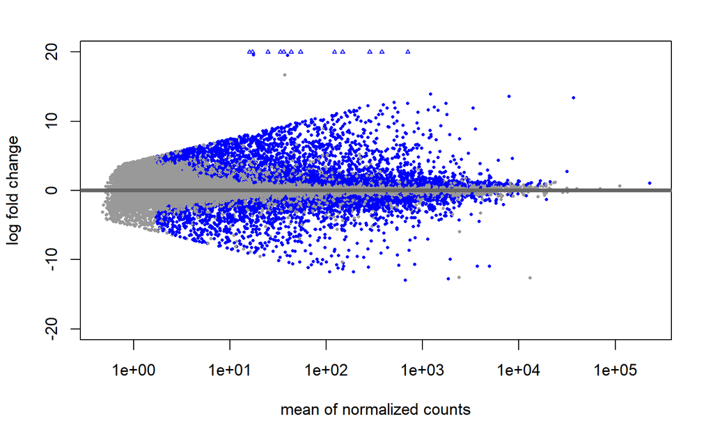

```r
plotMA(dds, ylim=c(-20,20))
```

- The genes with a significant DE are colored in blue.
- The large log2 foldchanges, especially for genes with lower mean count values, should be noted. Genes with less information, such as those with a low number of counts or high dispersion values, are unlikely to be as accurate as genes with more information.
- We can use log2foldchange shrinkage to improve the estimated fold changes.

#### LFC shrinkage

for genes with low amount of data available, shrinkage utilizes information from all genes to provide more likely, lower, log2 fold change estimates, similar to what we performed with dispersion.

```r
dds1_LFC <- lfcShrink(dds,
                      coef = "con_radial_vs_normal" ,
                      res = dds1_res)
```

```
using 'apeglm' for LFC shrinkage. If used in published research, please cite:
    Zhu, A., Ibrahim, J.G., Love, M.I. (2018) Heavy-tailed prior distributions for
    sequence count data: removing the noise and preserving large differences.
    Bioinformatics. https://doi.org/10.1093/bioinformatics/bty895
```

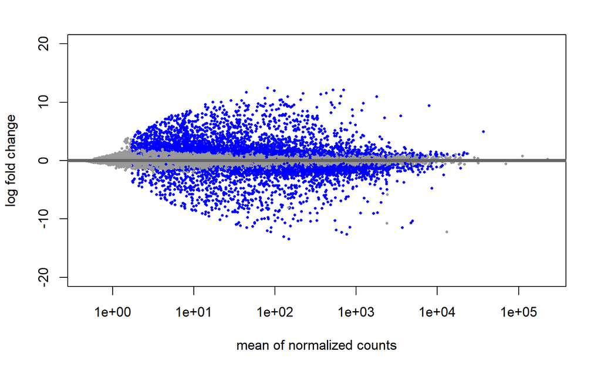

```r
plotMA(dds1_LFC, ylim=c(-20,20))
```

- The log2fold change values are now more restricted, especially for lowly expressed genes.
- The shrunken log2foldchanges should be more precise; however, shrinking the log2 foldchanges will not affect the number of differentially expressed genes returned, only the log2 fold change values. Now we can retrieve the significant DE genes and perform further visualization of results.

### DESeq2 results table

#### getting the description for the columns in the results table

```r
mcols(dds1_LFC)
```

```
DataFrame with 5 rows and 2 columns
                       type            description
                <character>            <character>
baseMean       intermediate mean of normalized c..
log2FoldChange      results log2 fold change (MA..
lfcSE               results posterior SD: con ra..
pvalue              results Wald test p-value: c..
padj                results   BH adjusted p-values
```

#### determine siginificant DE gene

- We will use the p-value adjusted for the multiple test correction. Because, every gene tested with alpha equals to 0.05, meanst that there is a 5% chance that the gene is called as a DE when it is not, returning false positives. For this reason, multiple test correction is performed by DESeq2 using Benjamin-Hochberg, or BH-method, to adjust the p-values for multiple testing and control the proportion of false postives relative to true.
- If we had 1000 genes categorized as DE and used the BH-method with an alpha value of 0.05, we would expect 5% of the DE genes to be false positives or 50 genes.
- Prior to testing, DESeq2 automatically filters out genes that are unlikely to be actually differentially expressed, such as genes with zero counts across all samples, genes with low mean values across all samples, and genes with dramatic count outlines, to limit the number of genes tested.

```r
head(dds1_LFC,n =10 )
```

```
log2 fold change (MAP): con radial vs normal
Wald test p-value: con radial vs normal
DataFrame with 10 rows and 5 columns
                 baseMean log2FoldChange     lfcSE      pvalue
                <numeric>      <numeric> <numeric>   <numeric>
ENSG00000223972   1.78799       0.132969  0.885471 0.721434541
ENSG00000227232   7.01446       0.350785  0.604942 0.463934557
ENSG00000241860   1.98683       0.381369  0.901971 0.407652728
ENSG00000279457   5.70124       1.183497  0.769140 0.040467446
ENSG00000228463   5.49010      -1.436076  1.310678 0.041837426
ENSG00000237094   8.96601       0.562235  0.843891 0.280379678
ENSG00000225972   5.58042       0.564300  0.788241 0.286326887
ENSG00000225630  38.66330      -2.618253  0.785182 0.000084522
ENSG00000237973 141.47226      -0.136626  0.572538 0.763457237
ENSG00000229344  94.37507       0.194176  0.689321 0.692876738
                       padj
                  <numeric>
ENSG00000223972 0.851775139
ENSG00000227232 0.663016611
ENSG00000241860 0.612445520
ENSG00000279457 0.130239006
ENSG00000228463 0.133405074
ENSG00000237094 0.483646137
ENSG00000225972 0.490378302
ENSG00000225630 0.000990717
ENSG00000237973 0.880374602
ENSG00000229344 0.832377164
```

The filtered genes are denoted by a NA in the p-adjusted column in the results table.

#### Siginificant DE genes summary

```r
summary(dds1_LFC)
```

```
out of 26574 with nonzero total read count
adjusted p-value < 0.1
LFC > 0 (up)       : 3063, 12%
LFC < 0 (down)     : 2972, 11%
outliers [1]       : 7, 0.026%
low counts [2]     : 5152, 19%
(mean count < 2)
[1] see 'cooksCutoff' argument of ?results
[2] see 'independentFiltering' argument of ?results
```

Over 1000 genes are DE which is the sum of log fold changes less than zero and greater than zero.

```r
summary(dds1_LFC, alpha = 0.05)
```

```
out of 26574 with nonzero total read count
adjusted p-value < 0.05
LFC > 0 (up)       : 2308, 8.7%
LFC < 0 (down)     : 2401, 9%
outliers [1]       : 7, 0.026%
low counts [2]     : 5152, 19%
(mean count < 2)
[1] see 'cooksCutoff' argument of ?results
[2] see 'independentFiltering' argument of ?results
```

##### Testing for siginifcant genes using both an alpha value threshold and a log2fold change threshold different from 0

A log2fold change threshold could be used to return genes that are most likely to be biologically meaningful. A log2fold change threshold isn’t always the best choice. It can, however, be useful when dealing with huge numbers of DE genes.

```r
#Rerun results function, Using 1.25 foldchange threshold which is 0.32 in the log2 scale
#dds1_res <- results(dds,
 #                  contrast = c("con", "radial", "normal"),
  #                  alpha = 0.05,
#                    lfcThreshold = 0.32)
#head(dds1_res)
```

```r
resultsNames(dds)
```

```
[1] "Intercept"                "con_metastasis_vs_normal"
[3] "con_radial_vs_normal"     "con_vertical_vs_normal"
```

```r
#Reshrink the foldchanges
dds1_LFC <- lfcShrink(dds,
                      coef = "con_radial_vs_normal",
                      res = dds1_res)
```

```
using 'apeglm' for LFC shrinkage. If used in published research, please cite:
    Zhu, A., Ibrahim, J.G., Love, M.I. (2018) Heavy-tailed prior distributions for
    sequence count data: removing the noise and preserving large differences.
    Bioinformatics. https://doi.org/10.1093/bioinformatics/bty895
```

```r
# Turn results table into a data frame
dds1_res_df <- data.frame(dds1_LFC)
head (dds1_res_df)
```

|  | baseMean | log2FoldChange | lfcSE | pvalue | padj |
| --- | --- | --- | --- | --- | --- |
| ENSG00000223972 | 1.787989 | 0.1329691 | 0.8854707 | 0.72143454 | 0.8517751 |
| ENSG00000227232 | 7.014458 | 0.3507850 | 0.6049423 | 0.46393456 | 0.6630166 |
| ENSG00000241860 | 1.986826 | 0.3813693 | 0.9019711 | 0.40765273 | 0.6124455 |
| ENSG00000279457 | 5.701238 | 1.1834972 | 0.7691399 | 0.04046745 | 0.1302390 |
| ENSG00000228463 | 5.490095 | -1.4360759 | 1.3106781 | 0.04183743 | 0.1334051 |
| ENSG00000237094 | 8.966015 | 0.5622349 | 0.8438907 | 0.28037968 | 0.4836461 |

|  | baseMean <dbl> | log2FoldChange <dbl> | lfcSE <dbl> | pvalue <dbl> | padj <dbl> |
| --- | --- | --- | --- | --- | --- |
| ENSG00000223972 | 1.787989 | 0.1329691 | 0.8854707 | 0.72143454 | 0.8517751 |
| ENSG00000227232 | 7.014458 | 0.3507850 | 0.6049423 | 0.46393456 | 0.6630166 |
| ENSG00000241860 | 1.986826 | 0.3813693 | 0.9019711 | 0.40765273 | 0.6124455 |
| ENSG00000279457 | 5.701238 | 1.1834972 | 0.7691399 | 0.04046745 | 0.1302390 |
| ENSG00000228463 | 5.490095 | -1.4360759 | 1.3106781 | 0.04183743 | 0.1334051 |
| ENSG00000237094 | 8.966015 | 0.5622349 | 0.8438907 | 0.28037968 | 0.4836461 |

6 rows

#### Ordering the genes by padjusted values for GSEA

```r
dds1_GSEA <- dds1_res_df %>% arrange(padj)
```

#### save the dds1_res object in a table to use it for GSEA

```r
#write.table(dds1_res, file = "DE_VGP_MET.txt", sep = " ", col.names = NA)
```

```r
#grcm38
```

```r
dds1_res_anno <- rownames_to_column(dds1_res_df, var = "ensgene")
head(dds1_res_anno)
```

|  | ensgene | baseMean | log2FoldChange | lfcSE | pvalue | padj |
| --- | --- | --- | --- | --- | --- | --- |
| 1 | ENSG00000223972 | 1.787989 | 0.1329691 | 0.8854707 | 0.72143454 | 0.8517751 |
| 2 | ENSG00000227232 | 7.014458 | 0.3507850 | 0.6049423 | 0.46393456 | 0.6630166 |
| 3 | ENSG00000241860 | 1.986826 | 0.3813693 | 0.9019711 | 0.40765273 | 0.6124455 |
| 4 | ENSG00000279457 | 5.701238 | 1.1834972 | 0.7691399 | 0.04046745 | 0.1302390 |
| 5 | ENSG00000228463 | 5.490095 | -1.4360759 | 1.3106781 | 0.04183743 | 0.1334051 |
| 6 | ENSG00000237094 | 8.966015 | 0.5622349 | 0.8438907 | 0.28037968 | 0.4836461 |

|  | ensgene <chr> | baseMean <dbl> | log2FoldChange <dbl> | lfcSE <dbl> | pvalue <dbl> | padj <dbl> |
| --- | --- | --- | --- | --- | --- | --- |
| 1 | ENSG00000223972 | 1.787989 | 0.1329691 | 0.8854707 | 0.72143454 | 0.8517751 |
| 2 | ENSG00000227232 | 7.014458 | 0.3507850 | 0.6049423 | 0.46393456 | 0.6630166 |
| 3 | ENSG00000241860 | 1.986826 | 0.3813693 | 0.9019711 | 0.40765273 | 0.6124455 |
| 4 | ENSG00000279457 | 5.701238 | 1.1834972 | 0.7691399 | 0.04046745 | 0.1302390 |
| 5 | ENSG00000228463 | 5.490095 | -1.4360759 | 1.3106781 | 0.04183743 | 0.1334051 |
| 6 | ENSG00000237094 | 8.966015 | 0.5622349 | 0.8438907 | 0.28037968 | 0.4836461 |

6 rows

```r
hm_annotables <- grch38[, c( "ensgene", "symbol", "description")]

dds_test <- merge(dds1_res_anno, hm_annotables, by.x = "ensgene", by.y = "ensgene", all.x = T )
```

```r
#dds_test <- dds_test%>% dplyr::select(-ends_with(".y"))
```

```r
head(dds_test)
```

|  | ensgene | baseMean | log2FoldChange | lfcSE | pvalue | padj | symbol | description |
| --- | --- | --- | --- | --- | --- | --- | --- | --- |
| 1 | ENSG00000000003 | 571.66860 | 0.87041284 | 0.4815263 | 3.874260e-02 | 0.125803292 | TSPAN6 | tetraspanin 6 |
| 2 | ENSG00000000419 | 1748.17647 | 0.52449759 | 0.4018190 | 1.519862e-01 | 0.325413268 | DPM1 | dolichyl-phosphate mannosyltransferase subunit 1, catalytic |
| 3 | ENSG00000000457 | 180.21557 | 1.43813743 | 0.3818214 | 5.129922e-05 | 0.000650043 | SCYL3 | SCY1 like pseudokinase 3 |
| 4 | ENSG00000000460 | 534.67620 | 0.08498325 | 0.2994136 | 7.698350e-01 | 0.883638824 | C1orf112 | chromosome 1 open reading frame 112 |
| 5 | ENSG00000000971 | 13.81695 | 1.25149478 | 1.0308212 | 4.970123e-02 | 0.151470901 | CFH | complement factor H |
| 6 | ENSG00000001036 | 444.54055 | -0.13173487 | 0.2296575 | 5.518713e-01 | 0.734103036 | FUCA2 | alpha-L-fucosidase 2 |

|  | ensgene <chr> | baseMean <dbl> | log2FoldChange <dbl> | lfcSE <dbl> | pvalue <dbl> | padj <dbl> | symbol <chr> |  |
| --- | --- | --- | --- | --- | --- | --- | --- | --- |
| 1 | ENSG00000000003 | 571.66860 | 0.87041284 | 0.4815263 | 3.874260e-02 | 0.125803292 | TSPAN6 |  |
| 2 | ENSG00000000419 | 1748.17647 | 0.52449759 | 0.4018190 | 1.519862e-01 | 0.325413268 | DPM1 |  |
| 3 | ENSG00000000457 | 180.21557 | 1.43813743 | 0.3818214 | 5.129922e-05 | 0.000650043 | SCYL3 |  |
| 4 | ENSG00000000460 | 534.67620 | 0.08498325 | 0.2994136 | 7.698350e-01 | 0.883638824 | C1orf112 |  |
| 5 | ENSG00000000971 | 13.81695 | 1.25149478 | 1.0308212 | 4.970123e-02 | 0.151470901 | CFH |  |
| 6 | ENSG00000001036 | 444.54055 | -0.13173487 | 0.2296575 | 5.518713e-01 | 0.734103036 | FUCA2 |  |

6 rows | 1-8 of 8 columns

```r
NA
```

```r
head(grch38)
```

| ensgene | entrez | symbol | chr | start | end | strand | biotype | description |
| --- | --- | --- | --- | --- | --- | --- | --- | --- |
| ENSG00000000003 | 7105 | TSPAN6 | X | 100627108 | 100639991 | -1 | protein_coding | tetraspanin 6 |
| ENSG00000000005 | 64102 | TNMD | X | 100584936 | 100599885 | 1 | protein_coding | tenomodulin |
| ENSG00000000419 | 8813 | DPM1 | 20 | 50934867 | 50959140 | -1 | protein_coding | dolichyl-phosphate mannosyltransferase subunit 1, catalytic |
| ENSG00000000457 | 57147 | SCYL3 | 1 | 169849631 | 169894267 | -1 | protein_coding | SCY1 like pseudokinase 3 |
| ENSG00000000460 | 55732 | C1orf112 | 1 | 169662007 | 169854080 | 1 | protein_coding | chromosome 1 open reading frame 112 |
| ENSG00000000938 | 2268 | FGR | 1 | 27612064 | 27635185 | -1 | protein_coding | FGR proto-oncogene, Src family tyrosine kinase |

| ensgene <chr> | entrez <int> | symbol <chr> | chr <chr> | start <int> | end <int> | strand <int> | biotype <chr> |  |
| --- | --- | --- | --- | --- | --- | --- | --- | --- |
| ENSG00000000003 | 7105 | TSPAN6 | X | 100627108 | 100639991 | -1 | protein_coding |  |
| ENSG00000000005 | 64102 | TNMD | X | 100584936 | 100599885 | 1 | protein_coding |  |
| ENSG00000000419 | 8813 | DPM1 | 20 | 50934867 | 50959140 | -1 | protein_coding |  |
| ENSG00000000457 | 57147 | SCYL3 | 1 | 169849631 | 169894267 | -1 | protein_coding |  |
| ENSG00000000460 | 55732 | C1orf112 | 1 | 169662007 | 169854080 | 1 | protein_coding |  |
| ENSG00000000938 | 2268 | FGR | 1 | 27612064 | 27635185 | -1 | protein_coding |  |

6 rows | 1-8 of 9 columns

```r
dds1_res_anno <- left_join(x = dds1_res_anno,
                 y = grch38[ , c("ensgene", "symbol", "description")],
                  by = c("ensgene"))
```

#### Remove Duplicates

```r
#non_duplicates <- which(duplicated(ids$symbol) == FALSE)
```

```r
head(dds1_res_anno)
```

|  | ensgene | baseMean | log2FoldChange | lfcSE | pvalue | padj | symbol | description |
| --- | --- | --- | --- | --- | --- | --- | --- | --- |
| 1 | ENSG00000223972 | 1.787989 | 0.1329691 | 0.8854707 | 0.7214345 | 0.8517751 | DDX11L1 | DEAD/H-box helicase 11 like 1 (pseudogene) |
| 2 | ENSG00000223972 | 1.787989 | 0.1329691 | 0.8854707 | 0.7214345 | 0.8517751 | DDX11L1 | DEAD/H-box helicase 11 like 1 (pseudogene) |
| 3 | ENSG00000223972 | 1.787989 | 0.1329691 | 0.8854707 | 0.7214345 | 0.8517751 | DDX11L1 | DEAD/H-box helicase 11 like 1 (pseudogene) |
| 4 | ENSG00000223972 | 1.787989 | 0.1329691 | 0.8854707 | 0.7214345 | 0.8517751 | DDX11L1 | DEAD/H-box helicase 11 like 1 (pseudogene) |
| 5 | ENSG00000223972 | 1.787989 | 0.1329691 | 0.8854707 | 0.7214345 | 0.8517751 | DDX11L1 | DEAD/H-box helicase 11 like 1 (pseudogene) |
| 6 | ENSG00000227232 | 7.014458 | 0.3507850 | 0.6049423 | 0.4639346 | 0.6630166 | WASH7P | WASP family homolog 7, pseudogene |

|  | ensgene <chr> | baseMean <dbl> | log2FoldChange <dbl> | lfcSE <dbl> | pvalue <dbl> | padj <dbl> | symbol <chr> |  |
| --- | --- | --- | --- | --- | --- | --- | --- | --- |
| 1 | ENSG00000223972 | 1.787989 | 0.1329691 | 0.8854707 | 0.7214345 | 0.8517751 | DDX11L1 |  |
| 2 | ENSG00000223972 | 1.787989 | 0.1329691 | 0.8854707 | 0.7214345 | 0.8517751 | DDX11L1 |  |
| 3 | ENSG00000223972 | 1.787989 | 0.1329691 | 0.8854707 | 0.7214345 | 0.8517751 | DDX11L1 |  |
| 4 | ENSG00000223972 | 1.787989 | 0.1329691 | 0.8854707 | 0.7214345 | 0.8517751 | DDX11L1 |  |
| 5 | ENSG00000223972 | 1.787989 | 0.1329691 | 0.8854707 | 0.7214345 | 0.8517751 | DDX11L1 |  |
| 6 | ENSG00000227232 | 7.014458 | 0.3507850 | 0.6049423 | 0.4639346 | 0.6630166 | WASH7P |  |

6 rows | 1-8 of 8 columns

```r
head(dds1_LFC)
```

```
log2 fold change (MAP): con radial vs normal
Wald test p-value: con radial vs normal
DataFrame with 6 rows and 5 columns
                 baseMean log2FoldChange     lfcSE    pvalue
                <numeric>      <numeric> <numeric> <numeric>
ENSG00000223972   1.78799       0.132969  0.885471 0.7214345
ENSG00000227232   7.01446       0.350785  0.604942 0.4639346
ENSG00000241860   1.98683       0.381369  0.901971 0.4076527
ENSG00000279457   5.70124       1.183497  0.769140 0.0404674
ENSG00000228463   5.49010      -1.436076  1.310678 0.0418374
ENSG00000237094   8.96601       0.562235  0.843891 0.2803797
                     padj
                <numeric>
ENSG00000223972  0.851775
ENSG00000227232  0.663017
ENSG00000241860  0.612446
ENSG00000279457  0.130239
ENSG00000228463  0.133405
ENSG00000237094  0.483646
```

```r
head(grch38)
```

| ensgene | entrez | symbol | chr | start | end | strand | biotype | description |
| --- | --- | --- | --- | --- | --- | --- | --- | --- |
| ENSG00000000003 | 7105 | TSPAN6 | X | 100627108 | 100639991 | -1 | protein_coding | tetraspanin 6 |
| ENSG00000000005 | 64102 | TNMD | X | 100584936 | 100599885 | 1 | protein_coding | tenomodulin |
| ENSG00000000419 | 8813 | DPM1 | 20 | 50934867 | 50959140 | -1 | protein_coding | dolichyl-phosphate mannosyltransferase subunit 1, catalytic |
| ENSG00000000457 | 57147 | SCYL3 | 1 | 169849631 | 169894267 | -1 | protein_coding | SCY1 like pseudokinase 3 |
| ENSG00000000460 | 55732 | C1orf112 | 1 | 169662007 | 169854080 | 1 | protein_coding | chromosome 1 open reading frame 112 |
| ENSG00000000938 | 2268 | FGR | 1 | 27612064 | 27635185 | -1 | protein_coding | FGR proto-oncogene, Src family tyrosine kinase |

| ensgene <chr> | entrez <int> | symbol <chr> | chr <chr> | start <int> | end <int> | strand <int> | biotype <chr> |  |
| --- | --- | --- | --- | --- | --- | --- | --- | --- |
| ENSG00000000003 | 7105 | TSPAN6 | X | 100627108 | 100639991 | -1 | protein_coding |  |
| ENSG00000000005 | 64102 | TNMD | X | 100584936 | 100599885 | 1 | protein_coding |  |
| ENSG00000000419 | 8813 | DPM1 | 20 | 50934867 | 50959140 | -1 | protein_coding |  |
| ENSG00000000457 | 57147 | SCYL3 | 1 | 169849631 | 169894267 | -1 | protein_coding |  |
| ENSG00000000460 | 55732 | C1orf112 | 1 | 169662007 | 169854080 | 1 | protein_coding |  |
| ENSG00000000938 | 2268 | FGR | 1 | 27612064 | 27635185 | -1 | protein_coding |  |

6 rows | 1-8 of 9 columns

#### Extracting the siginficant DE genes

```r
dds1_sig <- subset(dds1_res_anno, padj < 0.05)
```

#### Ordering the genes by padjusted values

```r
dds1_sig <- dds1_sig %>% arrange(padj)
```

#### Exploring the final table

```r
View(dds1_sig)
```

```r
dds1_first20 <- dds1_sig[1:20,]
View(dds1_first20)
write.csv(dds1_first20, "dds1_first20.csv", row.names = F)
```

### Visualization of the results

#### Expression heatmap

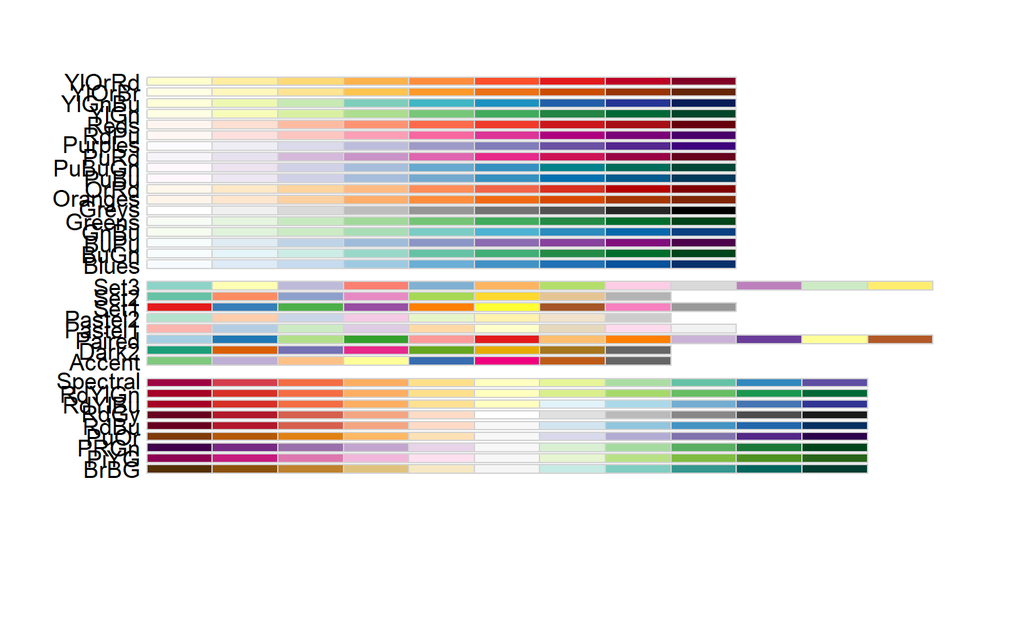

```r
# Subset normalized counts to significant genes
sig1_norm_counts <- norm_counts[dds1_sig$ensgene,]

# Choose a color palette from RColorBrewerlibrary(RColorBrewer)
heat_colors <- brewer.pal(6,"YlOrRd")
display.brewer.all()
```

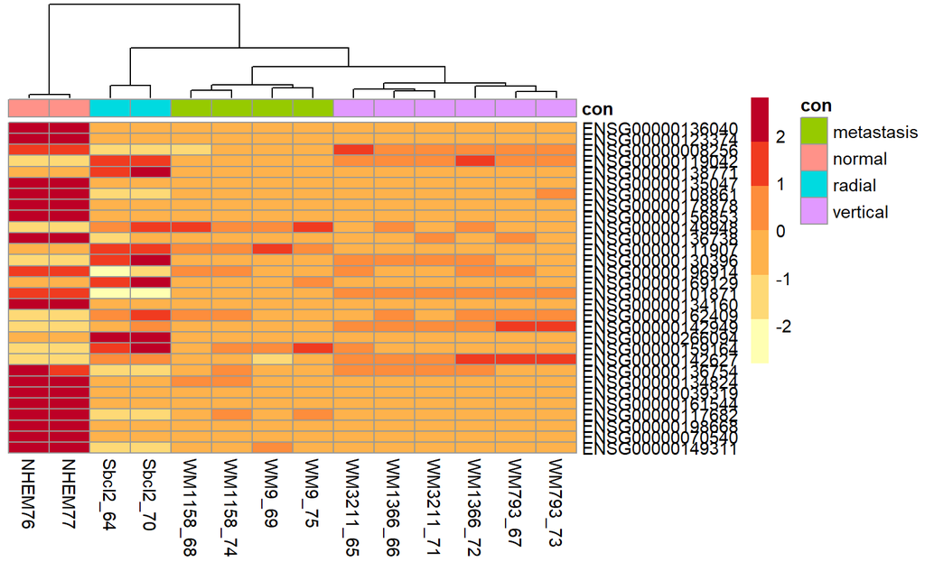

```r
# Run pheatmap
pheatmap(sig1_norm_counts[1:30,],
         color = heat_colors,
         cluster_rows =F,
         show_rownames =T,
         annotation = dplyr::select(colData, con),
         scale ="row")
```

```r
rld<- rlogTransformation(dds)
head(assay(rld))
```

```
                    NHEM76     NHEM77  Sbcl2_64  Sbcl2_70 WM1366_66
ENSG00000223972 0.59199618 -0.2475137 0.5982058 0.2624646  1.238528
ENSG00000227232 2.65519006  2.5390191 2.9659902 2.8402982  2.883771
ENSG00000241860 0.07606271  0.6071246 0.8101048 0.7889924  1.150871
ENSG00000279457 2.04768637  2.3607590 3.3946150 2.9942330  2.018953
ENSG00000228463 2.76019786  2.9639344 1.1767126 1.6998418  3.235212
ENSG00000237094 2.05828030  1.5864318 2.4208884 2.3893842  3.215220
                WM1366_72 WM3211_65  WM3211_71  WM793_67  WM793_73
ENSG00000223972  1.142079 0.4705563 -0.1237509 0.3304930 0.3015933
ENSG00000227232  2.883422 3.0371637  2.4531576 2.3373055 2.4466286
ENSG00000241860  1.332886 0.6969742  0.6241054 0.8766034 0.8394052
ENSG00000279457  1.577442 1.9135689  2.5849665 2.3133343 2.0960224
ENSG00000228463  2.019581 2.7474891  1.6624998 2.3398594 1.5198851
ENSG00000237094  3.791069 2.9359794  3.3425277 1.6105970 2.2993169
                    WM9_69    WM9_75 WM1158_68 WM1158_74
ENSG00000223972 -0.2332217 1.2210628 0.4700582 0.7969234
ENSG00000227232  2.5157238 3.2636258 2.9828250 2.6826526
ENSG00000241860  1.0332529 0.3052228 1.6796610 0.6579017
ENSG00000279457  2.6768982 2.3263161 2.2865932 2.1127464
ENSG00000228463  2.1095090 2.5062586 1.3374956 0.8738203
ENSG00000237094  3.1422104 3.4776052 3.4220916 3.7207741
```

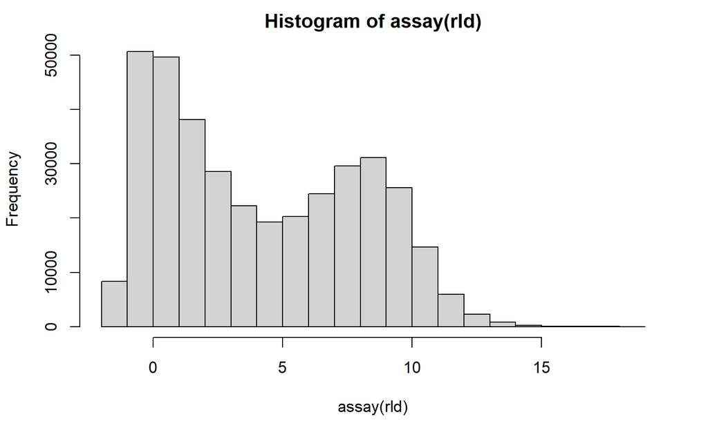

```r
hist(assay(rld))
```

```r
sampleDists <- as.matrix(dist(t(assay(rld))))
```

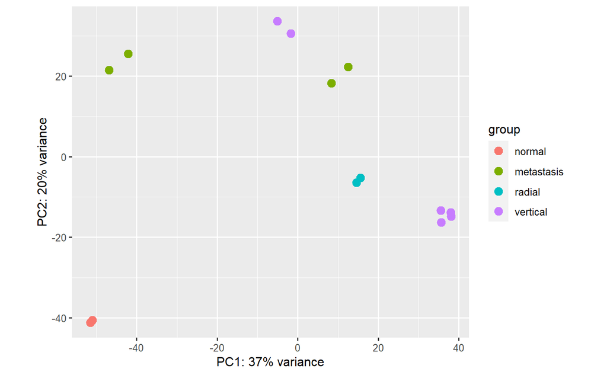

```r
plotPCA(rld, intgroup="con")
```

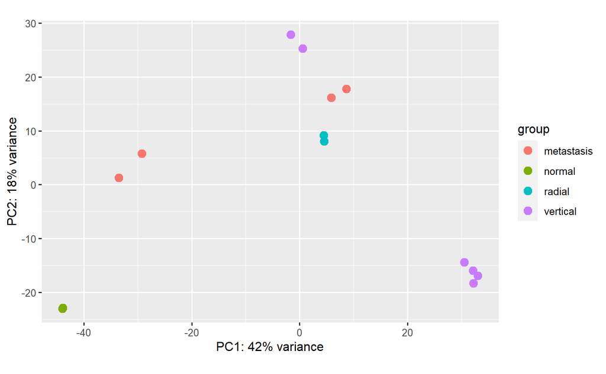

```r
plotPCA(vsd, intgroup = 'con')
```

we (select) the genes for the heatmap in (order) and this order is selected by (rowMeans) and select the (count) of my deseq data set (normalized) to library size and we want (decreasing) to have info about all upregulated and down regulated genes and set the number to present or to visualize [1:50] then we have to transform my normalized count and we select log2.norm.counts which i will use in the heatmap and then tell the heatmap that the annotation_col is the df (annotation_col=df)

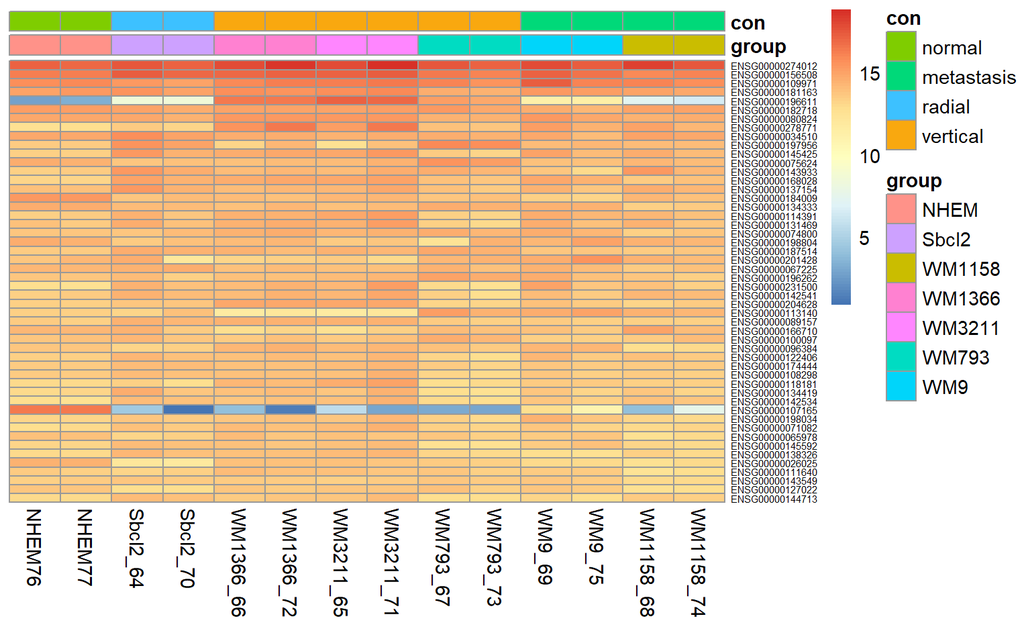

```r
#rowmeans is wrong ????
select1 <- order(rowMeans(counts(dds,normalized=TRUE)),decreasing=TRUE) [1:50]
nt <- normTransform(dds) # defaults to log2(x+1)
log2.norm.counts <- assay(nt)[select1,]
df <- as.data.frame(colData(dds)[,c("group","con")])
pheatmap(log2.norm.counts, cluster_rows=FALSE, show_rownames=TRUE,
cluster_cols=FALSE, annotation_col=df, fontsize_row = 5)
```

From the heatmap we can Know the expression level of genes: Dark blue indicates very low expressed genes light blue indicates low expressed genes Red indicates very highly expressed genes

#### Heatmap of regularized log transformed dds counts

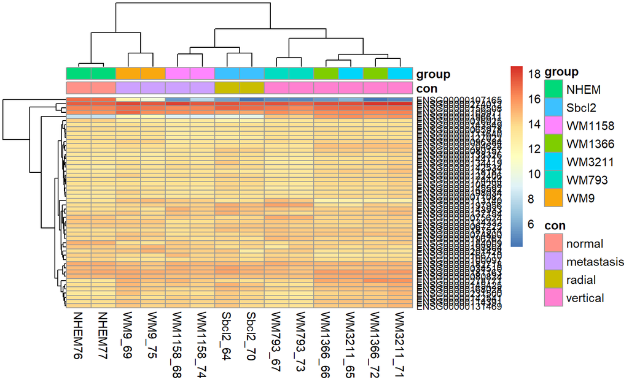

```r
df <- as.data.frame(colData(rld)[,c("con","group")])
pheatmap(assay(rld)[select1,], cluster_rows=T, show_rownames=TRUE,
cluster_cols=T, annotation_col=df, fontsize_row =8)
```

```r
top1_20 <- data.frame(sig1_norm_counts)[1:20,]  %>% rownames_to_column(var ="ensgene")
#key column will be a seperate column
top1_20 <- gather(top1_20, key ="samplename", value ="normalized_counts",2:4)
```

```r
#head(sig1_norm_counts)
```

```r
top1_20 <- inner_join(top1_20, rownames_to_column(colData, var ="samplename"),                     by ="samplename")
```

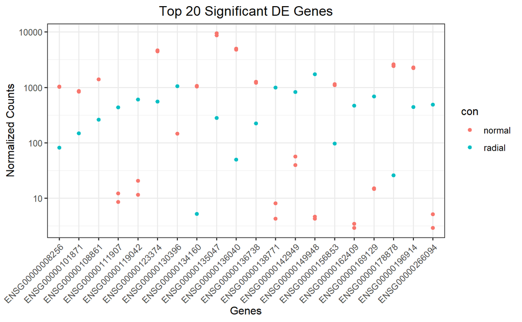

```r
ggplot(top1_20)+
  geom_point(aes(x = ensgene, y = normalized_counts, color = con))+        scale_y_log10()+
  xlab("Genes")+
  ylab("Normalized Counts")+
  ggtitle("Top 20 Significant DE Genes")+
  theme_bw()+
  theme(axis.text.x = element_text(angle =45, hjust =1))+
  theme(plot.title = element_text(hjust =0.5))
```

# Test

#good idea is to make symbol as rownames

```r
#top1_20_symbol <- data.frame(sig1_norm_counts)[1:20,]  %>% rownames_to_column(var ="symbol")
#top1_20_symbol <- gather(top1_20, key ="samplename", value ="normalized_counts",2:4)
```

```r
#top1_20_symbol <- data.frame(sig1_norm_symbol)[1:60,]  %>% rownames_to_column(var ="symbol")
#top1_20_symbol <- gather(top1_20_symbol, key ="samplename", value ="normalized_counts",2:4)
```

```r
#top1_20_symbol <- inner_join(top1_20_symbol, rownames_to_column(colData, var ="samplename"),                     by ="samplename")
```

```r
#head(top1_20_smybol)
```

```r
# adding symbol to norm counts
#sig1_norm_symbol <- rownames_to_column(dds1_res_df, var = "ensgene")

#pick symbol from gr38
#sig1_norm_symbol <- left_join(x = sig1_norm_symbol,
        #         y = grch38[ , c("ensgene", "symbol")],
         #         by = c("ensgene"))
#
#remove duplicates
#sig1_norm_symbol <- unique(sig1_norm_symbol)

#Order by p-adjusted Value
#sig1_norm_symbol <- sig1_norm_symbol %>% arrange(padj)

#get 1st 50
#sig1_norm_symbol <- sig1_norm_symbol[1:70,]

#change symbol to be rownames insted of ensembl ids
#row.names(sig1_norm_symbol) <- sig1_norm_symbol$symbol

#remove last column
#sig1_norm_symbol <- sig1_norm_symbol[,-7]
```

#another try

```r
## Subset normalized counts to significant genes
sig1_norm_symbol <- norm_counts[dds1_sig$ensgene,]

#apply this to norm counts
sig1_norm_symbol <- rownames_to_column(as.data.frame(sig1_norm_symbol), var = "ensgene")

#pick symbol from gr38
sig1_norm_symbol <- left_join(x =  sig1_norm_symbol,
                 y = grch38[ , c("ensgene", "symbol")],
                  by = c("ensgene"))

#remove duplicates
sig1_norm_symbol <- unique(sig1_norm_symbol)
```

```r
top1_20_symbol <- data.frame(sig1_norm_symbol)[1:20,]  %>% rownames_to_column(var ="ids")

#remove ids column
top1_20_symbol <- top1_20_symbol[,-1]

#key column will be a seperate column
top1_20_symbol <- gather(top1_20_symbol, key ="samplename", value ="normalized_counts",2:4)
```

```r
top1_20_symbol <- inner_join(top1_20_symbol, rownames_to_column(colData, var ="samplename"),                     by ="samplename")
```

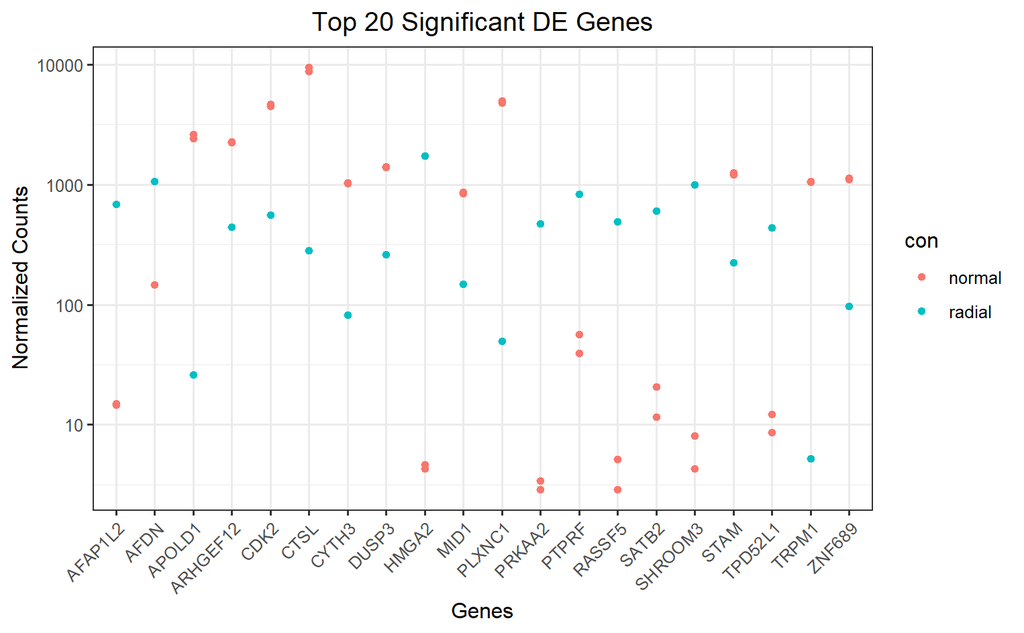

```r
ggplot(top1_20_symbol)+
  geom_point(aes(x = symbol, y = normalized_counts, color = con))+        scale_y_log10()+
  xlab("Genes")+
  ylab("Normalized Counts")+
  ggtitle("Top 20 Significant DE Genes")+
  theme_bw()+
  theme(axis.text.x = element_text(angle =45, hjust =1))+
  theme(plot.title = element_text(hjust =0.5))
```

#### Heatmap

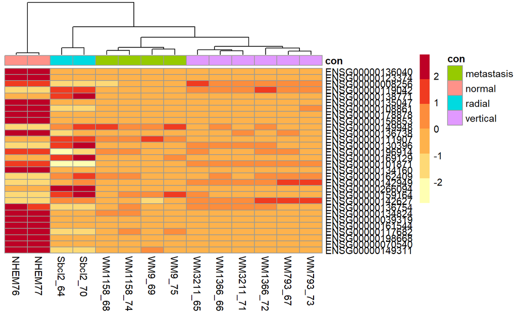

```r
# Run pheatmap
pheatmap(sig1_norm_counts[1:30,],
         color = heat_colors,
         cluster_rows =F,
         show_rownames =T,
         annotation = dplyr::select(colData, con),
         scale ="row")
```

```r
head(sig1_norm_counts)
```

```
                    NHEM76      NHEM77  Sbcl2_64   Sbcl2_70 WM1366_66
ENSG00000136040 4982.02798 4788.983166  49.38698   53.27192   25.3786
ENSG00000123374 4500.69744 4672.714822 556.25340  526.89255  885.0788
ENSG00000008256 1040.59893 1029.061608  81.44520   95.72298  762.9443
ENSG00000119042   20.55504   11.568989 604.77394  598.47669  453.6426
ENSG00000138771    4.28230    8.098293 997.27050 1432.51513   68.2050
ENSG00000135047 9487.00772 8739.793049 280.72601  357.08832  607.5003
                WM1366_72 WM3211_65 WM3211_71   WM793_67  WM793_73
ENSG00000136040  38.58537  33.78052  35.52636   37.26932  32.04139
ENSG00000123374 948.88514 867.48375 877.84480  844.44438 905.39826
ENSG00000008256 690.59939 906.66916 694.48296  823.84818 789.13377
ENSG00000119042 572.48091 408.06868 500.80702  488.42428 496.18388
ENSG00000138771  92.91987  48.64395  68.76069   58.84630  69.57560
ENSG00000135047 724.46002 664.80063 755.22157 1059.23337 632.58868
                   WM9_69     WM9_75 WM1158_68  WM1158_74
ENSG00000136040   49.8626   49.79399  65.05817   68.08078
ENSG00000123374  724.5856  689.64674 693.95380  852.86652
ENSG00000008256  340.8329  338.59912 267.68726  299.55544
ENSG00000119042  217.1232  243.99054 321.22471  257.46914
ENSG00000138771  134.4397  201.66565 168.06694  196.81535
ENSG00000135047 1449.8023 1175.13812 828.13628 1067.01152
```

```r
head(sig1_norm_symbol)
```

|  | ensgene | NHEM76 | NHEM77 | Sbcl2_64 | Sbcl2_70 | WM1366_66 | WM1366_72 | WM3211_65 | WM3211_71 | WM793_67 | WM793_73 | WM9_69 | WM9_75 | WM1158_68 | WM1158_74 | symbol |
| --- | --- | --- | --- | --- | --- | --- | --- | --- | --- | --- | --- | --- | --- | --- | --- | --- |
| 1 | ENSG00000136040 | 4982.02798 | 4788.983166 | 49.38698 | 53.27192 | 25.3786 | 38.58537 | 33.78052 | 35.52636 | 37.26932 | 32.04139 | 49.8626 | 49.79399 | 65.05817 | 68.08078 | PLXNC1 |
| 2 | ENSG00000123374 | 4500.69744 | 4672.714822 | 556.25340 | 526.89255 | 885.0788 | 948.88514 | 867.48375 | 877.84480 | 844.44438 | 905.39826 | 724.5856 | 689.64674 | 693.95380 | 852.86652 | CDK2 |
| 3 | ENSG00000008256 | 1040.59893 | 1029.061608 | 81.44520 | 95.72298 | 762.9443 | 690.59939 | 906.66916 | 694.48296 | 823.84818 | 789.13377 | 340.8329 | 338.59912 | 267.68726 | 299.55544 | CYTH3 |
| 4 | ENSG00000119042 | 20.55504 | 11.568989 | 604.77394 | 598.47669 | 453.6426 | 572.48091 | 408.06868 | 500.80702 | 488.42428 | 496.18388 | 217.1232 | 243.99054 | 321.22471 | 257.46914 | SATB2 |
| 5 | ENSG00000138771 | 4.28230 | 8.098293 | 997.27050 | 1432.51513 | 68.2050 | 92.91987 | 48.64395 | 68.76069 | 58.84630 | 69.57560 | 134.4397 | 201.66565 | 168.06694 | 196.81535 | SHROOM3 |
| 6 | ENSG00000135047 | 9487.00772 | 8739.793049 | 280.72601 | 357.08832 | 607.5003 | 724.46002 | 664.80063 | 755.22157 | 1059.23337 | 632.58868 | 1449.8023 | 1175.13812 | 828.13628 | 1067.01152 | CTSL |

|  | ensgene <chr> | NHEM76 <dbl> | NHEM77 <dbl> | Sbcl2_64 <dbl> | Sbcl2_70 <dbl> | WM1366_66 <dbl> | WM1366_72 <dbl> | WM3211_65 <dbl> |  |
| --- | --- | --- | --- | --- | --- | --- | --- | --- | --- |
| 1 | ENSG00000136040 | 4982.02798 | 4788.983166 | 49.38698 | 53.27192 | 25.3786 | 38.58537 | 33.78052 |  |
| 2 | ENSG00000123374 | 4500.69744 | 4672.714822 | 556.25340 | 526.89255 | 885.0788 | 948.88514 | 867.48375 |  |
| 3 | ENSG00000008256 | 1040.59893 | 1029.061608 | 81.44520 | 95.72298 | 762.9443 | 690.59939 | 906.66916 |  |
| 4 | ENSG00000119042 | 20.55504 | 11.568989 | 604.77394 | 598.47669 | 453.6426 | 572.48091 | 408.06868 |  |
| 5 | ENSG00000138771 | 4.28230 | 8.098293 | 997.27050 | 1432.51513 | 68.2050 | 92.91987 | 48.64395 |  |
| 6 | ENSG00000135047 | 9487.00772 | 8739.793049 | 280.72601 | 357.08832 | 607.5003 | 724.46002 | 664.80063 |  |

6 rows | 1-9 of 16 columns

```r
#remove duplicates
sig1_norm_symbol <- unique(sig1_norm_symbol)

#get 1st 50
sig1_norm_symbol <- sig1_norm_symbol[1:70,]

#change symbol to be rownames instead of ensembl ids
row.names(sig1_norm_symbol) <- sig1_norm_symbol$symbol

#remove first and last column
sig1_norm_symbol <- sig1_norm_symbol[,c(-1,-16)]
```

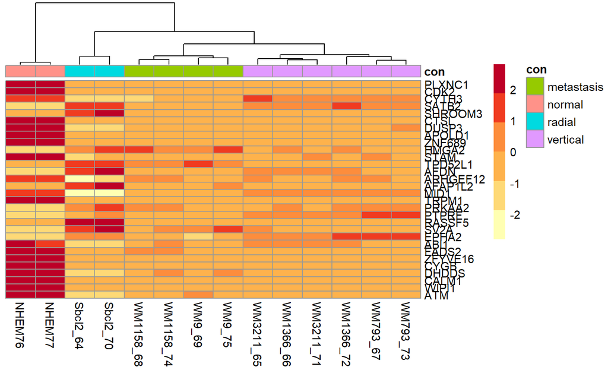

```r
# Run pheatmap
pheatmap(sig1_norm_symbol[1:30,],
         color = heat_colors,
         cluster_rows =F,
         show_rownames =T,
         annotation = dplyr::select(colData, con),
         scale ="row")
```

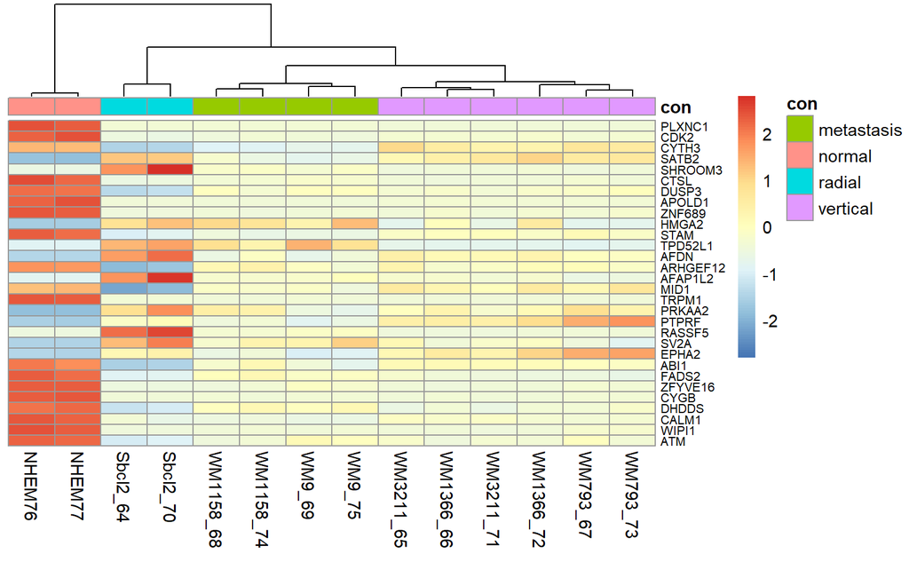

```r
pheatmap(sig1_norm_symbol[1:30,],
         #color = heat_colors,
         cluster_rows =F,
         show_rownames =T,
         annotation = dplyr::select(colData, con),cluster_cols=T,               fontsize_row = 7,
         scale ="row")
```

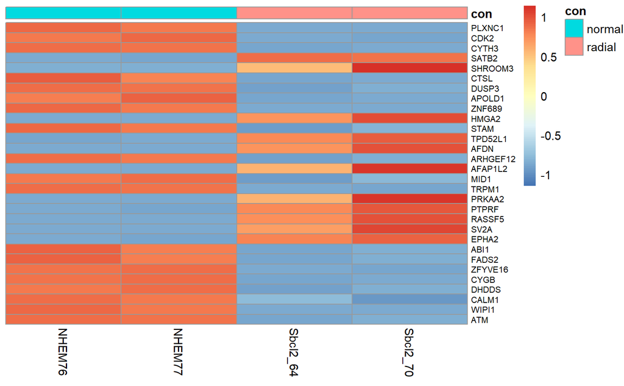

```r
# Run pheatmap
pheatmap(sig1_norm_symbol[1:30,1:4],
         #color = heat_colors,
         cluster_rows =F,
         cluster_cols = F,
         show_rownames =T,
         annotation = dplyr::select(colData, con),
         fontsize_row = 7,
         scale ="row")
```